# Regression

Peter Stella

Fall 2019

# Lab Section

In this lab, we will go over regression. We will be using the caret package in R. https://topepo.github.io/caret/train-models-by-tag.html

# Perfomance Metrics

## Residual

Deviation of the observed value to the estimated value (sample mean)
$$residual=y_i - \hat{y_i}$$
where $\hat{y_i}$ is the estimated value

## Mean Squared Error (MSE)

$$MSE=\frac{1}{n}\sum_{i=1}^{n}(y_i - \hat{y_i})^2$$

## Root Mean Squared Error (RMSE)

Same units as original data.

$$RMSE=\sqrt{MSE}$$

## L2 regularization : Ridge regression. Regularize by adding the sum of the coefficients, squared, to the function.

$$Ridge Regression=\sum_{i=1}^{n}(y_i - w_0 - \sum_{j=1}^{p}w_jx_{ij})^2 + \lambda\sum_{j=1}^p(w_j)^2$$

## L1 regularization : Lasso Regression. Regularize by adding the sum of the absolute value of the coefficients to the model. Coefficient estimates may be pushed to zero – Lasso can perform variable selection

$$Lasso Regression=\sum_{i=1}^{n}(y_i - w_0 - \sum_{j=1}^{p}w_jx_{ij})^2 + \lambda\sum_{j=1}^p|w_j|$$

### The broad steps of Machine learning in R.

1. Split the data into training and test. Set test aside.
2. Fit a good model to the training data.
3. See how your model did on the training data.
4. Test how your model performs on the test data.

# Regression

1. Split data into training and test set (75% in train set, 25% in test set)

```r
airquality$group = sample.int(4,size = nrow(airquality), replace= TRUE)
train_regression = filter(airquality,group < 4)
test_regression = filter(airquality,group == 4)
```

### Linear Regression

- Assumes a linear relationship.
- Independent variables should not be correlated (no mulitcollinearity)
- The number of observations should be greater than the number of independent variables.

$$RSS=\sum(y_i - \hat{y_i})^2$$
We will predict the response of the Temperature based on Wind.

This is the data we will fit a linear model to.

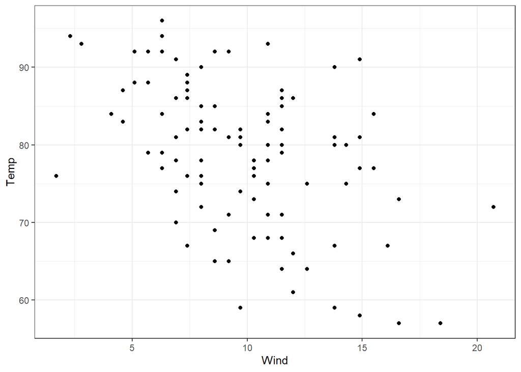

```r
ggplot(data = train_regression) +
geom_point(aes(x=Wind, y=Temp)) +
theme_bw()
```

2. Create and fit a linear model to predict Temperature from Wind using the training set

```r
linear_regression <- train( Temp ~ Wind , data=train_regression, method = "lm")
```

```r
coef <- linear_regression$finalModel$coefficients
coef[[1]]
```

```
## [1] 90.02748
```

```r
coef[[2]]
```

```
## [1] -1.137258
```

3. Vizualize how your model performed on the train data by plotting the regression line on top of the train data points.

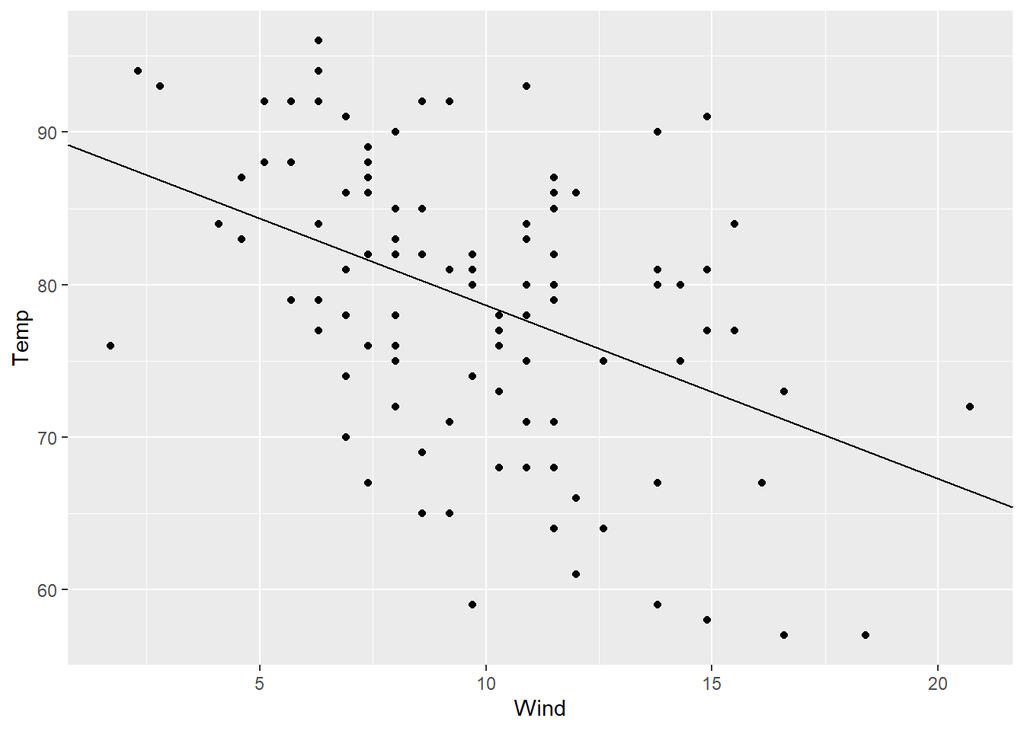

```r
ggplot(train_regression, aes(Wind, Temp)) + geom_point() +geom_abline(intercept = coef[[1]], slope = coef[[2]])
```

4. Explore how the model performs on the test data. For Linear Regression:
- The residuals should be close to zero. They are not, really.

```r
summary(linear_regression$finalModel$residuals)
```

```
##    Min. 1st Qu.  Median    Mean 3rd Qu.    Max.
## -19.996  -5.737   1.235   0.000   5.912  17.918
```

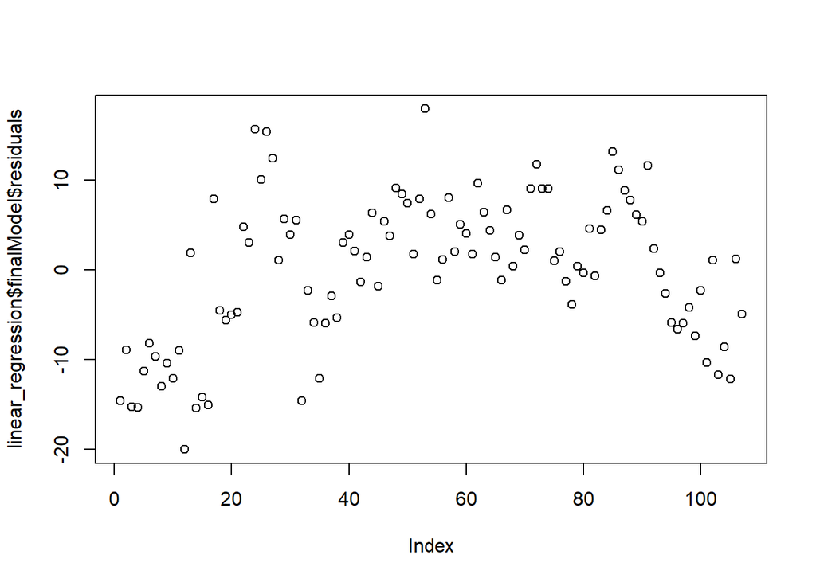

```r
plot(linear_regression$finalModel$residuals)
```

- There should be equal variance around the regression line (homoscedasticity). Plot 3 (scale/location) shows some heteroscedsaticity,i.e. not purely flat line

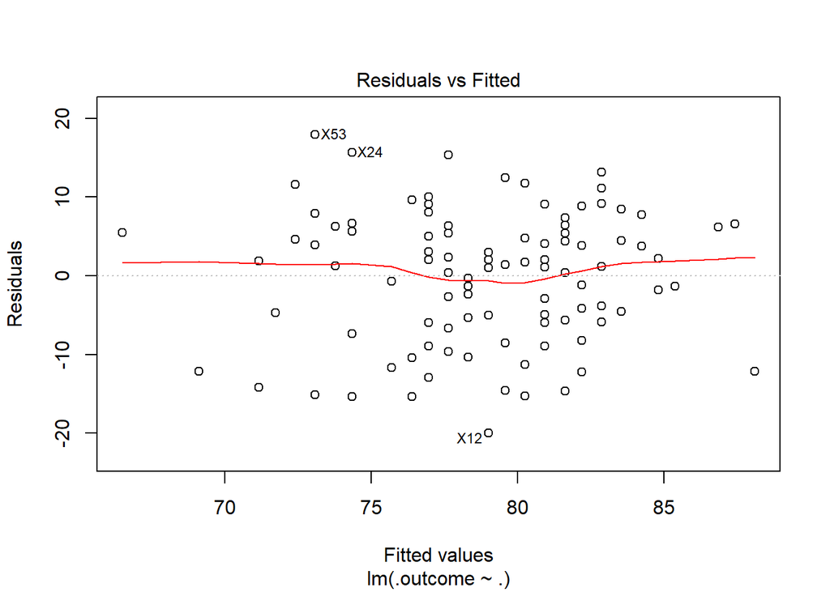

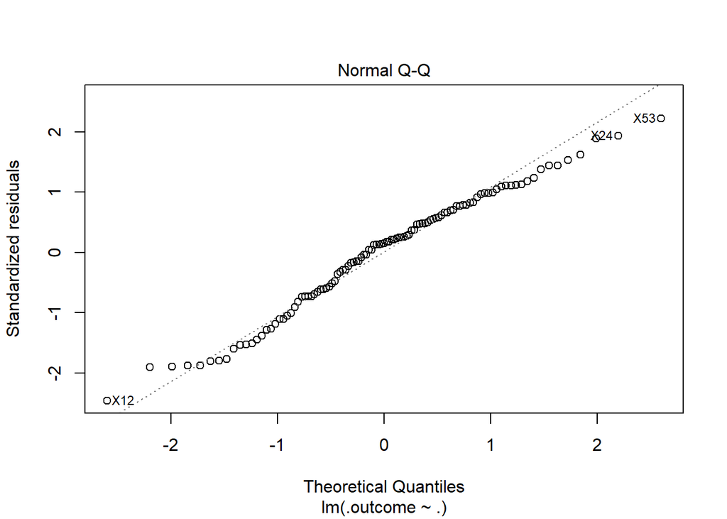

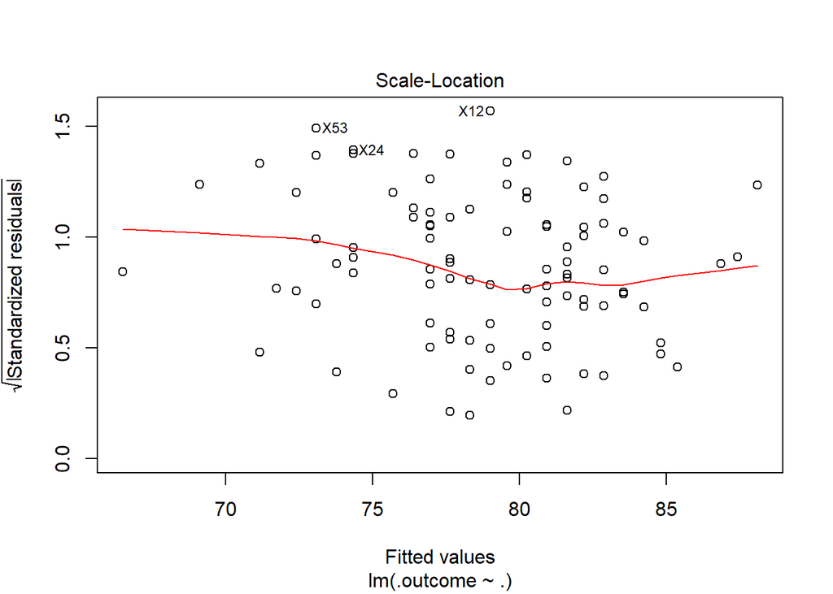

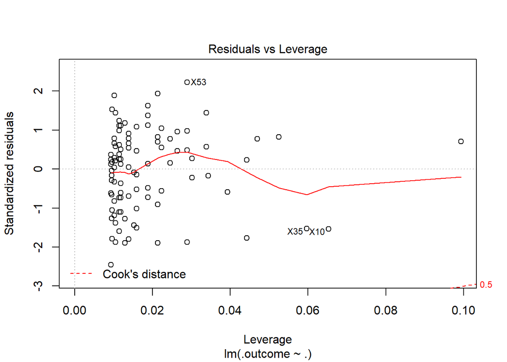

```r
plot(linear_regression$finalModel)
```

- Residuals should be normally distributed. This is pretty much true (as the QQ plot shows)
- Independent variables and residuals should not be correlated. They do not appear to be.

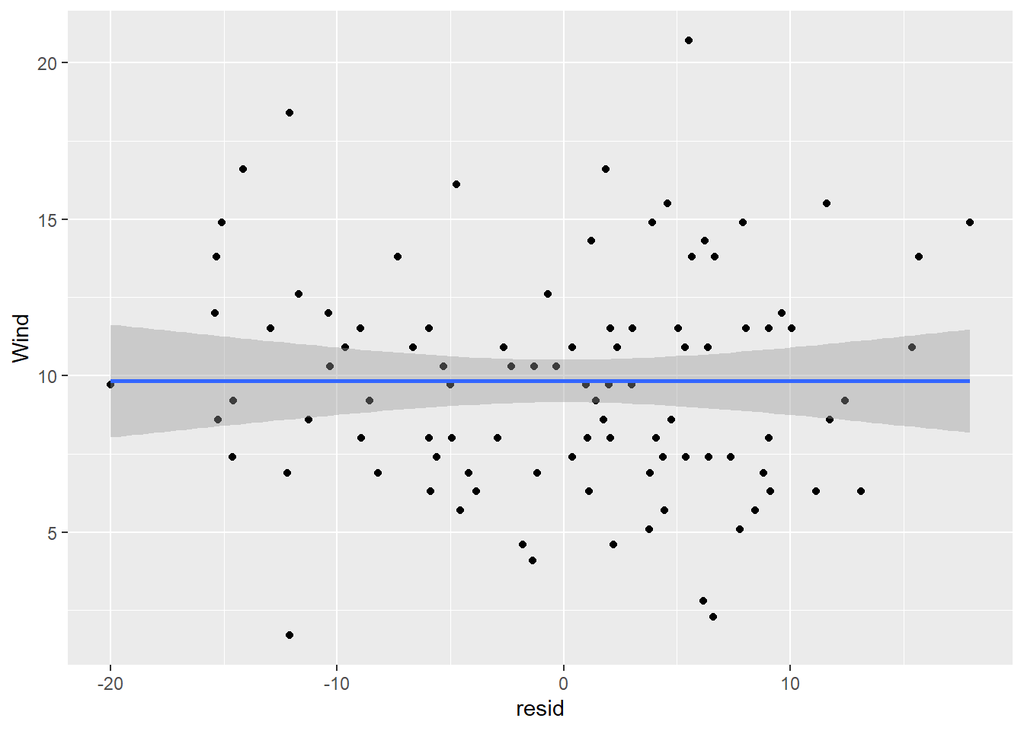

```r
restrain <- train_regression[,c("Temp", "Wind")]
restrain$resid <- linear_regression$finalModel$residuals
ggplot(restrain, aes(resid, Wind)) + geom_point() +geom_smooth(method =lm)
```

4 a) See how the model performs on the test data

```r
linear_predict <- predict(linear_regression, newdata= test_regression)
testvspredict <- cbind(test_regression, linear_predict)
testvspredict <- testvspredict %>% mutate(resid= Temp - linear_predict)
```

4 b) Look at the residuals. Are they close to zero? Not really

```r
summary(testvspredict$resid)
```

```
##    Min. 1st Qu.  Median    Mean 3rd Qu.    Max.
## -23.929  -8.642  -1.731  -2.730   3.665  18.004
```

4 c) Plot predicted temperature vs observed temperature. A strong model should show a strong correlation

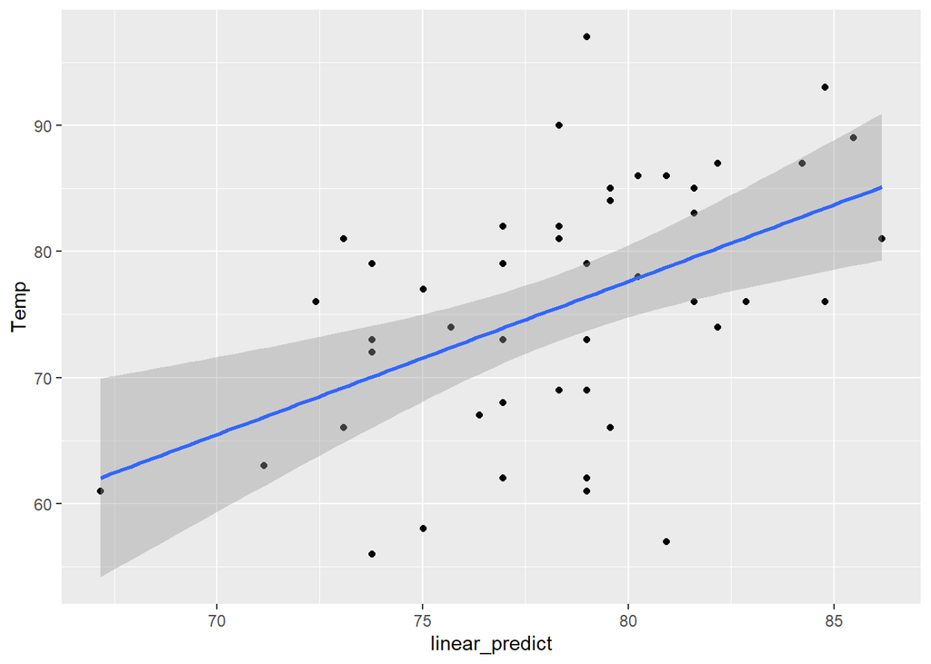

```r
ggplot(testvspredict, aes(linear_predict, Temp)) + geom_point() +geom_smooth(method =lm)
```

4 d) Visualize the predicted values in relation to the real data points. Look for homoscedasticity

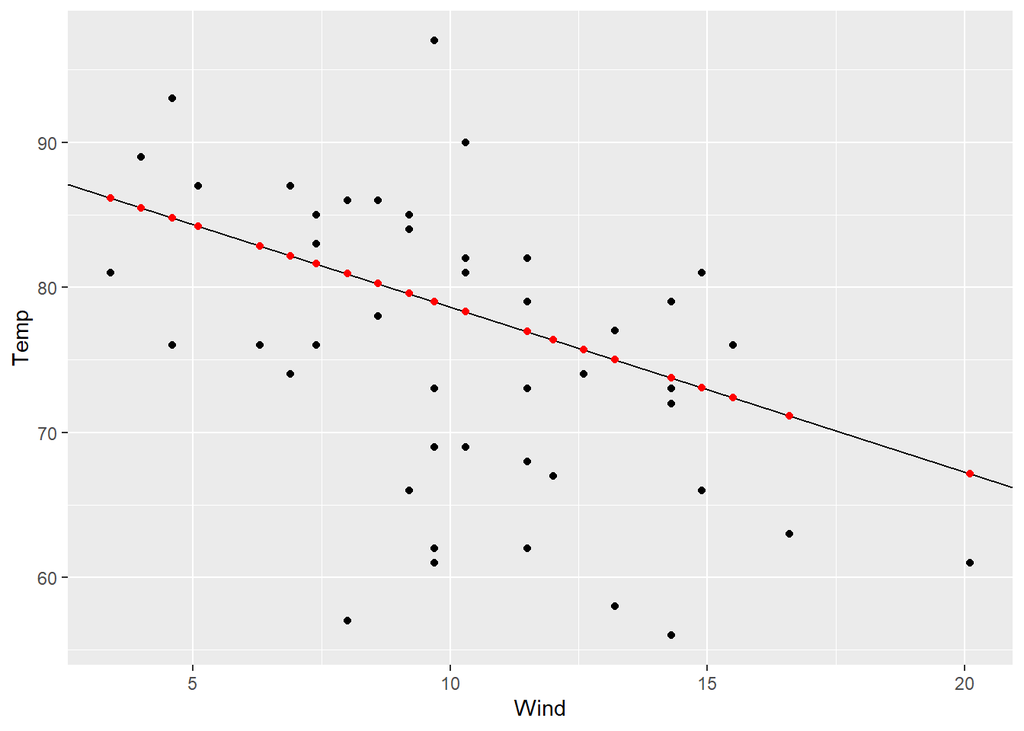

```r
# probably a stupid way of doing this, but easier for me to rename variables and then just change data sources in ggplot
linear_predict2 <- test_regression %>% select(Wind)
linear_predict2 <- cbind(linear_predict2, linear_predict)
colnames(linear_predict2)[2] <- "Temp"

# Extract coefficients from the model
# plot the regression line on the predicted values
# plot the original test values

ggplot(test_regression, aes(Wind, Temp)) + geom_point() +geom_abline(intercept = coef[[1]], slope = coef[[2]]) +
geom_point(data=linear_predict2, color= "red")
```

4 e) Residuals should be normally distributed. Plot the density of the residuals

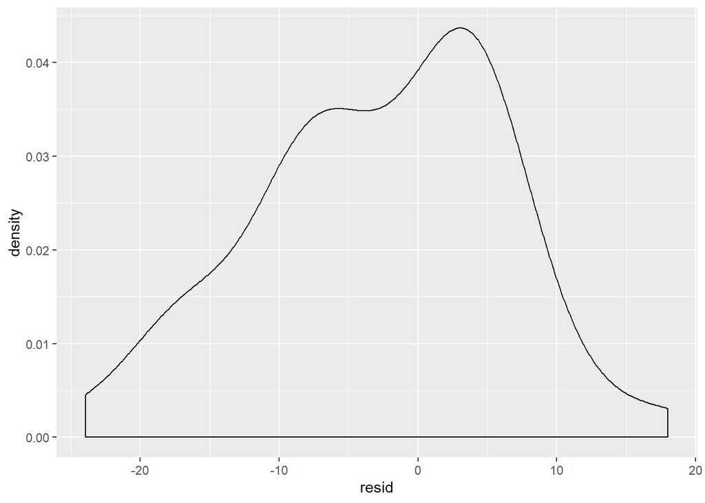

```r
residuals_lin <- residuals(linear_regression)
ggplot(data=testvspredict) +
 geom_density(aes(resid))
```

4 f) Independent variables and residuals should not be correlated

```r
cor.test(train_regression$Wind, resid(linear_regression))
```

```
##
##  Pearson's product-moment correlation
##
## data:  train_regression$Wind and resid(linear_regression)
## t = -5.8507e-15, df = 105, p-value = 1
## alternative hypothesis: true correlation is not equal to 0
## 95 percent confidence interval:
##  -0.1898584  0.1898584
## sample estimates:
##           cor
## -5.709736e-16
```

### Linear Regression with Regularization

5. Create a linear model using L1 or L2 regularization to predict Temperature from Wind and Month variables. Plot your predicted values and the real Y values on the same plot.

```r
library(glmnet)
library(Matrix)
```

I found this rather difficult to do in caret, but here I set a bunch of possible lambda values

```r
set.seed(123)
lambda <- 10^seq(-3, 3, length = 100)
```

and feed those to caret using glmnet for ridge (l2) regularization, outputting my final regression coefficients

```r
multi_regression <- train( Temp ~ (Month + Wind) , data=train_regression, method = "glmnet",trControl = trainControl("cv", number = 10), tuneGrid = expand.grid(alpha = 0, lambda = lambda))
coef(multi_regression$finalModel, multi_regression$bestTune$lambda)
```

```
## 3 x 1 sparse Matrix of class "dgCMatrix"
##                      1
## (Intercept) 75.1488822
## Month        1.8415705
## Wind        -0.9402733
```

predict test values, generate residuals, althoguh not used here

```r
multiple_predict <- predict(multi_regression, newdata= test_regression)
multivspredict <- cbind(test_regression, multiple_predict)
multivspredict <- multivspredict %>% mutate(resid= Temp - multiple_predict)
```

A very messy bit of wrangling to build a simple dataframe with temperature, wind and month data. I have recoded the “group” variable that I originally used to separate real from predicted data (predicted points are now group 1)

```r
multiple_predict2 <- test_regression %>% select(Wind, Month, group)
multiple_predict2 <- cbind(multiple_predict2, multiple_predict)
colnames(multiple_predict2)[4] <- "Temp"
multiple_predict2 <- multiple_predict2 %>% mutate(group = replace(group,, 1))
test_regression2 <- test_regression %>% select(Wind, Month, Temp, group)
multiple_predict2 <- rbind(multiple_predict2, test_regression2)
```

I wasn’t sure how you wanted me to plot the data here, but I thought faceting by month was probably the most informative.

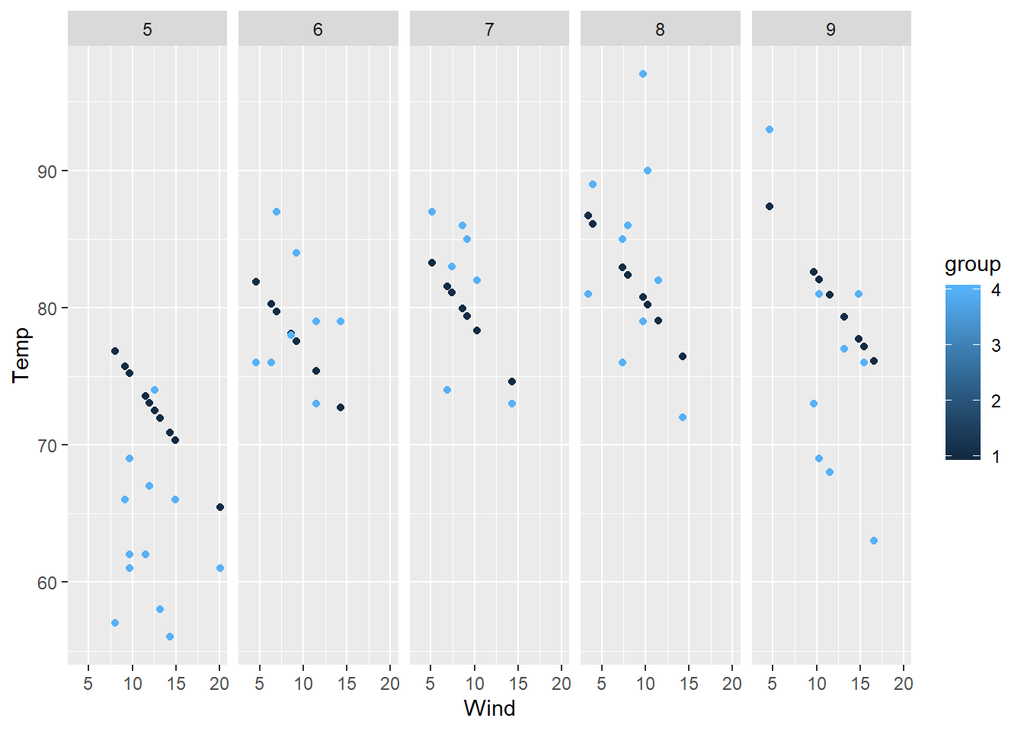

```r
p <- ggplot(multiple_predict2, aes(Wind, Temp)) + geom_point(aes(color=group))
p+facet_grid(cols= vars(Month))
```